# Chapter 19 Quasiquotation (metaprogramming)

Author

Yang Hu

## Introduction

Now that you understand the tree structure of R code, it’s time to return to one of the fundamental ideas that make `expr()` and `ast()` work: quotation. In tidy evaluation, all quoting functions are actually quasiquoting functions because they also support unquoting. Where quotation is the act of capturing an unevaluated expression, **unquotation** is the ability to selectively evaluate parts of an otherwise quoted expression. Together, this is called quasiquotation.

Quasiquotation makes it easy to create functions that combine code written by the function’s author with code written by the function’s user. This helps to solve a wide variety of challenging problems.

**Quasiquotation is one of the three pillars of tidy evaluation**. You’ll learn about the other two (**quosures** and the **data mask**) in Chapter 20. When used alone, quasiquotation is most useful for programming, particularly for generating code. But when it’s combined with the other techniques, tidy evaluation becomes a powerful tool for data analysis.

**Prerequisites**

Make sure you’ve read the metaprogramming overview in Chapter 17 to get a broad overview of the motivation and the basic vocabulary, and that you’re familiar with the tree structure of expressions as described in Section 18.3.

Code-wise, we’ll mostly be using the tools from rlang, but at the end of the chapter you’ll also see some powerful applications in conjunction with purrr.

```r
library(rlang)
library(purrr)
```

**Related work**

Quoting functions have deep connections to Lisp **macros**. But macros are usually run at compile-time, which doesn’t exist in R, and they always input and output ASTs. See Thomas Lumley95 for one approach to implementing them in R.

Quoting functions are more closely related to the more esoteric Lisp **fexprs**, functions where all arguments are quoted by default. These terms are useful to know when looking for related work in other programming languages.

## Motivation

We’ll start with a concrete example that helps motivate the need for unquoting, and hence quasiquotation. Imagine you’re creating a lot of strings by joining together words:

```r
paste("Good", "morning", "Yang")
```

```
[1] "Good morning Yang"
```

```r
paste("Good", "afternoon", "Yang")
```

```
[1] "Good afternoon Yang"
```

You are sick and tired of writing all those quotes, and instead you just want to use bare words. To that end, you’ve written the following function. (Don’t worry about the implementation for now; you’ll learn about the pieces later.)

```r
cement <- function(...) {
  args <- ensyms(...)
  paste(purrr::map(args, as_string), collapse = " ")
}

cement(Good, morning, Yang)
```

```
[1] "Good morning Yang"
```

Formally, this function quotes all of its inputs. You can think of it as automatically putting quotation marks around each argument. That’s not precisely true as the intermediate objects it generates are expressions, not strings, but it’s a useful approximation, and the root meaning of the term “quote”.

This function is nice because we no longer need to type quotation marks. The problem comes when we want to use variables. It’s easy to use variables with `paste()`: just don’t surround them with quotation marks.

```r
name <- "Yang"
time <- "morning"

paste("good", time, name)
```

```
[1] "good morning Yang"
```

Obviously this doesn’t work with `cement()` because every input is automatically quoted:

```r
cement(Good, time, name)
```

```
[1] "Good time name"
```

We need some way to explicitly unquote the input to tell `cement()` to remove the automatic quote marks. Here we need `time` and `name` to be treated differently to Good. Quasiquotation gives us a standard tool to do so: `!!`, called “unquote”, and pronounced bang-bang. `!!` tells a quoting function to drop the implicit quotes:

```r
# Use !! (bang-bang) to delay evaluation:
cement(Good, !!time, !!name)
```

```
[1] "Good morning Yang"
```

```r
my_list <- list(time, name)

# Use !!!(bang-bang-bang) to delay evaluation of a list:
cement(Good, !!!my_list)
```

```
[1] "Good morning Yang"
```

It’s useful to compare `cement()` and `paste()` directly. `paste()` evaluates its arguments, so we must quote where needed; `cement()` quotes its arguments, so we must unquote where needed.

```r
paste("Good", time, name)
```

```
[1] "Good morning Yang"
```

```r
cement(Good, !!time, !!name)
```

```
[1] "Good morning Yang"
```

### Vocabulary

The distinction between quoted and evaluated arguments is important:

- An **evaluated** argument obeys R’s usual evaluation rules.
- A **quoted** argument is captured by the function, and is processed in some custom way.

`paste()` evaluates all its arguments; `cement()` quotes all its arguments.

If you’re ever unsure about whether an argument is quoted or evaluated, try executing the code outside of the function. If it doesn’t work or does something different, then that argument is quoted. For example, you can use this technique to determine that the first argument to `library()` is quoted:

```r
library(MASS)

MASS
```

Talking about whether an argument is quoted or evaluated is a more precise way of stating whether or not a function uses non-standard evaluation (NSE). I will sometimes use “quoting function” as short-hand for a function that quotes one or more arguments, but generally, I’ll talk about quoted arguments since that is the level at which the difference applies.

### Excercises

1. For each function in the following base R code, identify which arguments are quoted and which are evaluated.

```r
# 1
library(MASS)

MASS  # It's quoted

# 2
mtcars2 <- subset(mtcars, cyl == 4)

mtcars    # It's evaluated
cyl == 4  # It's quoted

# 3
with(mtcars2, sum(vs))

sum(vs)   # It's quoted
vs        # It's quoted

# 4
sum(mtcars2$am)

mtcars2$am # It's evaluated
am         # It's quoted

# 5
rm(mtcars2)

mtcars2    # It's evaluated (if it's exists); or it's quoted if it's not exist
```

Note for the last one: When we inspect the source code of `rm()`, we notice that `rm()` catches its … argument as an unevaluated call (in this case a pairlist) via `match.call()`. This call is then converted into a string for further evaluation.

2. For each function in the following tidyverse code, identify which arguments are quoted and which are evaluated.

```r
library(dplyr)
library(ggplot2)

by_cyl <- mtcars %>%
  group_by(cyl) %>%
  summarise(mean = mean(mpg))

ggplot(by_cyl, aes(cyl, mean)) + geom_point()


# -------

dplyr     # Quoted
ggplot2   # Quoted

cyl       # Quoted
mean(mpg) # Quoted

by_cyl           # Evaluated
aes(cyl, mean)   # Evaluated
```

## Quoting

The first part of quasi-quotation is quotation: capturing an expression without evaluating it. We’ll need a pair of functions because the expression can be supplied directly or indirectly, via lazily-evaluated function argument. I’ll start with the rlang quoting functions, then circle back to those provided by base R.

### Capturing expressions

There are four important quoting functions. For interactive exploration, the most important is `expr()`, which captures its argument exactly as provided:

```r
expr(x + y)
```

```
x + y
```

```r
expr(1 / 2 / 3)
```

```
1/2/3
```

(Remember that white space and comments are not part of the expression, so will not be captured by a quoting function.)

`expr()` is great for interactive exploration, because it captures what you, the developer, typed. It’s not so useful inside a function:

```r
f1 <- function(x) {
  expr(x)
}

fi(a + b + c)
```

We need another function to solve this problem: `enexpr()`. This captures what the caller supplied to the function by looking at the internal promise object that powers lazy evaluation (Section 6.5.1).

```r
f2 <- function(x) {

  enexpr(x)
}

f2(a + b + c)
```

[output not shown]

(It’s called “en”-`expr()` by analogy to enrich. Enriching someone makes them richer; `enexpr()`ing a argument makes it an expression.)

To capture all arguments in …, use `enexprs()`.

```r
f <- function(...) {enexprs(...)}

f(x = 1, y = 10 * z)
```

```
$x
[1] 1

$y
10 * z
```

Finally, `exprs()` is useful interactively to make a list of expressions:

```r
exprs(x = x ^ 2, y = y ^ 3, z = z ^ 4)
```

```
$x
x^2

$y
y^3

$z
z^4
```

```r
# shorthand for
list(x = expr(x ^ 2), y = expr(y ^ 3), z = expr(z ^ 4))
```

```
$x
x^2

$y
y^3

$z
z^4
```

In short, use `enexpr()` and `enexprs()` to capture the expressions supplied as arguments by the user. Use `expr()` and `exprs()` to capture expressions that you supply.

### Capturing symbols

Sometimes you only want to allow the user to specify a variable name, not an arbitrary expression. In this case, you can use `ensym()` or `ensyms()`. These are variants of `enexpr()` and `enexprs()` that check the captured expression is either symbol or a string (which is converted to a symbol). `ensym()` and `ensyms()` throw an error if given anything else.

```r
f <- function(...) {
  ensyms(...)
}

f(x)
```

```
[[1]]
x
```

```r
f("Yang")
```

```
[[1]]
Yang
```

### With base R

Each rlang function described above has an equivalent in base R. Their primary difference is that the base equivalents do not support unquoting (which we’ll talk about very soon). This make them quoting functions, rather than quasiquoting functions.

The base equivalent of `expr()` is `quote()`:

```r
quote(1 + 1)
```

```
1 + 1
```

```r
expr(1 + 1)
```

```
1 + 1
```

The base function closest to `enexpr()` is `substitute()`:

```r
f3 <- function(x) {substitute(x)}

f3(1 + 1)
```

```
1 + 1
```

The base equivalent to `exprs()` is `alist()`:

```r
alist(x = 1, y = x + 2)
```

```
$x
[1] 1

$y
x + 2
```

```r
exprs(x = 1, y = x + 2)
```

```
$x
[1] 1

$y
x + 2
```

The equivalent to `enexprs()` is an undocumented feature of `substitute()`:

```r
f <- function(...) {as.list(substitute(...()))}

f(x = 1, y = 10 * z)
```

```
$x
[1] 1

$y
10 * z
```

There are two other important base quoting functions that we’ll cover elsewhere:

- `bquote()` provides a limited form of quasiquotation, and is discussed in Section 19.5.
- `~`, the formula, is a quoting function that also captures the environment. It’s the inspiration for quosures, the topic of the next chapter, and is discussed in Section 20.3.4.

### Substitution

You’ll most often see `substitute()` used to capture unevaluated arguments. However, as well as quoting, `substitute()` also does substitution (as its name suggests!). If you give it an expression, rather than a symbol, it will substitute in the values of symbols defined in the current environment.

```r
f4 <- function(x) {
  substitute(x * 2)
}

f4(a + b + c)
```

```
(a + b + c) * 2
```

I think this makes code hard to understand, because if it is taken out of context, you can’t tell if the goal of `substitute(x + y)` is to replace `x`, y`, or both. If you do want to use`substitute()` for substitution, I recommend that you use the second argument to make your goal clear:

```r
substitute(x * y * z, list(x = 10, y = quote(a + b)))
```

```
10 * (a + b) * z
```

rlang quasiquoting functions

|  | Developer | User |
| --- | --- | --- |
| One | `expr()` | `enexpr()` |
| Many | `expers()` | `enexprs()` |

base R quoting functions

|  | Developer | User |
| --- | --- | --- |
| One | `quote()` | `substitute()` |
| Many | `alist()` | `as.list(substitute(...()))` |

## Unquoting

So far, you’ve only seen relatively small advantages of the rlang quoting functions over the base R quoting functions: they have a more consistent naming scheme. The big difference is that rlang quoting functions are actually quasiquoting functions because they can also unquote.

Unquoting allows you to selectively evaluate parts of the expression that would otherwise be quoted, which effectively allows you to merge ASTs using a template AST. Since base functions don’t use unquoting, they instead use a variety of other techniques, which you’ll learn about in Section 19.5.

Unquoting is one inverse of quoting. It allows you to selectively evaluate code inside `expr()`, so that `expr(!!x)` is equivalent to `x`. In Chapter 20, you’ll learn about another inverse, evaluation. This happens outside `expr()`, so that `eval(expr(x))` is equivalent to `x`.

### Unquoting one argument

Use `!!` to unquote a single argument in a function call. `!!` takes a single expression, evaluates it, and inlines the result in the AST.

```r
x <- expr(-1)

expr(f(x, y))
```

```
f(x, y)
```

```r
expr(f(!!x, y))
```

```
f(-1, y)
```

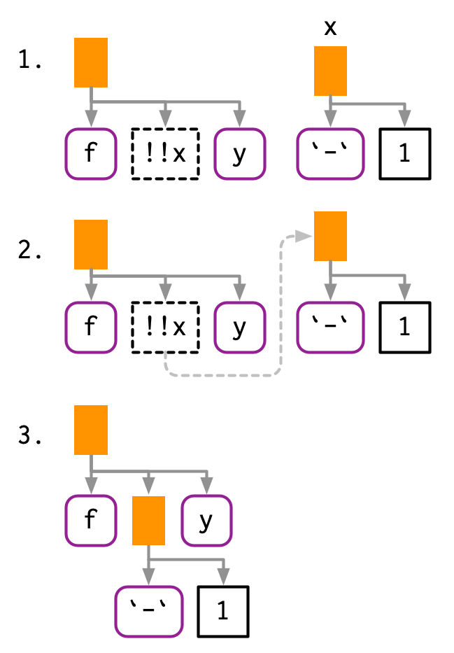

As well as call objects, `!!` also works with symbols and constants:

```r
a <- sym("y")

b <- 1

expr(f(!!a, !!b))
```

```
f(y, 1)
```

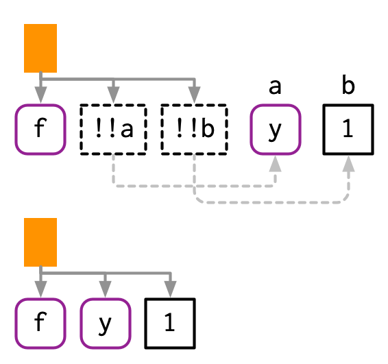

If the right-hand side of `!!` is a function call, `!!` will evaluate it and insert the results:

```r
expr(print("Today is", !!format(Sys.Date(), "%Y %m %d.")))
```

```
print("Today is", "2024 05 31.")
```

```r
x <- format(Sys.Date(), "%Y %m %d.")

expr(print("Today is", !!x))
```

```
print("Today is", "2024 05 31.")
```

`!!` preserves operator precedence because it works with expressions.

```r
gas <- 50

shopping <- 250

x1 <- expr(!!gas + !!shopping + 80)

expr(!!x1 / 2)
```

```
(50 + 250 + 80)/2
```

```r
# --

x1 <- expr(x + 1)
x2 <- expr(x + 2)

expr(!!x1 / !!x2)
```

```
(x + 1)/(x + 2)
```

If we simply pasted the text of the expressions together, we’d end up with `x + 1 / x + 2`, which has a very different AST:

```r
expr(x + 1 / x + 2)
```

```
x + 1/x + 2
```

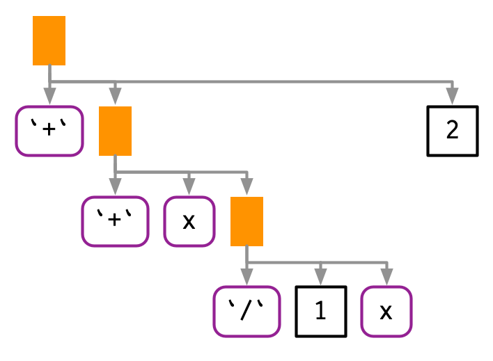

### Unquoting a function

`!!` is most commonly used to replace the arguments to a function, but you can also use it to replace the function. The only challenge here is operator precedence: `expr(!!f(x, y))` unquotes the result of `f(x, y)`, so you need an extra pair of parentheses.

```r
f <- expr(mean)

f
```

```
mean
```

```r
expr((!!f)(x,y))
```

```
mean(x, y)
```

```r
# --

f <- expr(foo)

expr((!!f)(x, y))
```

```
foo(x, y)
```

This also works when `f` is a call:

```r
f <- expr(pkg::foo)

expr((!!f)(x, y))
```

```
pkg::foo(x, y)
```

Because of the large number of parentheses involved, it can be clearer to use `rlang::call2()`:

```r
f <- expr(pkg::foo)

call2(f, expr(x), expr(y))
```

```
pkg::foo(x, y)
```

### Unquoting a missing argument

Very occasionally it is useful to unquote a missing argument (Section 18.6.2), but the naive approach doesn’t work:

```r
arg <- missing_arg()

expr(foo(!!arg, !!arg))
```

You can work around this with the `rlang::maybe_missing()` helper:

```r
expr(foo(!!maybe_missing(arg), !!maybe_missing(arg)))
```

### Unquoting in special forms

There are a few special forms where unquoting is a syntax error. Take `$` for example: it must always be followed by the name of a variable, not another expression. This means attempting to unquote with `$` will fail with a syntax error:

```r
x <- expr(Species)

expr(iris$!!x)
```

To make unquoting work, you’ll need to use the prefix form (Section 6.8.1):

```r
expr(`$`(iris, !!x))
```

[output not shown]

### Unquoting many arguments

`!!` is a one-to-one replacement. `!!!` (called “unquote-splice”, and pronounced bang-bang-bang) is a one-to-many replacement. It takes a list of expressions and inserts them at the location of the `!!!`:

```r
xs <- exprs(1, a, -b)

expr(f(!!!xs, y))
```

```
f(1, a, -b, y)
```

```r
# or with names:

ys <- set_names(xs, c("a", "b", "c"))

expr(f(!!!ys, d = 4))
```

```
f(a = 1, b = a, c = -b, d = 4)
```

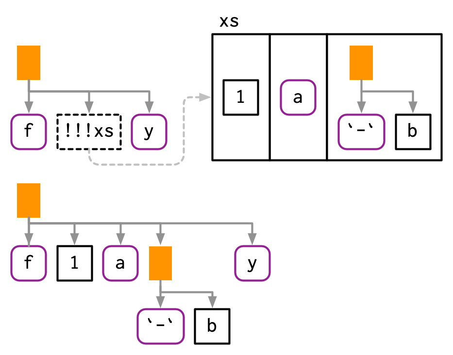

`!!!` can be used in any rlang function that takes `...` regardless of whether or not `...` is quoted or evaluated. We’ll come back to this in Section 19.6; for now note that this can be useful in `call2()`.

```r
call2("f", !!!xs, expr(y))
```

```
f(1, a, -b, y)
```

### The polite fiction of `!!`

So far we have acted as if `!!` and `!!!` are regular prefix operators like `+` , `-`, and `!`. They’re not. From R’s perspective, `!!` and `!!!` are simply the repeated application of `!`:

```r
!TRUE

!!TRUE

!!!TRUE
```

`!!` and `!!!` behave specially inside all quoting functions powered by rlang, where they behave like real operators with precedence equivalent to unary `+` and `-`. This requires considerable work inside rlang, but means that you can write `!!x + !!y` instead of `(!!x) + (!!y)`.

The biggest downside to using a fake operator is that you might get silent errors when misusing `!!` outside of quasiquoting functions. Most of the time this is not an issue because `!!` is typically used to unquote expressions or quosures. Since expressions are not supported by the negation operator, you will get an argument type error in this case:

```r
x <- quote(variable)

!!x
```

But you can get silently incorrect results when working with numeric values:

```r
df <- data.frame(x = 1:5)

y <- 100

with(df, x + !!y)
```

```
[1] 2 3 4 5 6
```

Given these drawbacks, you might wonder why we introduced new syntax instead of using regular function calls. Indeed, early versions of tidy evaluation used function calls like `UQ()` and `UQS()`. However, they’re not really function calls, and pretending they are leads to a misleading mental mode. We chose `!!` and `!!!` as the least-bad solution:

- They are visually strong and don’t look like existing syntax. When you see `!!x` or `!!!x` it’s clear that something unusual is happening.
- They override a rarely used piece of syntax, as double negation is not a common pattern in R99. If you do need it, you can just add parentheses `!(!x)`.

### Non-standard ASTs

With unquoting, it’s easy to create non-standard ASTs, i.e. ASTs that contain components that are not expressions. (It is also possible to create non-standard ASTs by directly manipulating the underlying objects, but it’s harder to do so accidentally.) These are valid, and occasionally useful, but their correct use is beyond the scope of this book. However, it’s important to learn about them, because they can be deparsed, and hence printed, in misleading ways.

For example, if you inline more complex objects, their attributes are not printed. This can lead to confusing output:

```r
x1 <- expr(class(!!data.frame(x = 10)))
x1
```

```
class(list(x = 10))
```

```
#> class(list(x = 10))
```

```r
eval(x1)
```

```
[1] "data.frame"
```

```
#> [1] "data.frame"
```

You have two main tools to reduce this confusion: `rlang::expr_print()` and `lobstr::ast()`:

```r
expr_print(x1)
```

```
class(<df[,1]>)
```

```
#> class(<df[,1]>)
```

```r
lobstr::ast(!!x1)
```

```
█─class
└─<inline data.frame>
```

```
#> █─class
#> └─<inline data.frame>
```

Another confusing case arises if you inline an integer sequence:

```r
x2 <- expr(f(!!c(1L, 2L, 3L, 4L, 5L)))
x2
```

```
f(1:5)
```

```r
expr_print(x2)
```

```
f(<int: 1L, 2L, 3L, 4L, 5L>)
```

```r
lobstr::ast(!!x2)
```

```
█─f
└─<inline integer>
```

### Exercises

```r
xy <- expr(x + y)
xz <- expr(x + z)
yz <- expr(y + z)
abc <- exprs(a, b, c)

# 1.
expr(!!xy / !!xz)
```

```
(x + y)/(x + z)
```

```r
# 2.
expr(-`^`(!!xz, !!yz))
```

```
-(x + z)^(y + z)
```

```r
# or
expr(-(!!xz) ^ !!(yz))
```

```
-(x + z)^(y + z)
```

```r
# 3.
expr(((!!xy)) + !!yz - !!xy)
```

```
(x + y) + (y + z) - (x + y)
```

```r
# 4.
expr(atan2(!!xy, !!yz))
```

```
atan2(x + y, y + z)
```

```r
# 5.
expr(sum(!!xy, !!xy, !!yz))
```

```
sum(x + y, x + y, y + z)
```

```r
# 6.
expr(sum(!!!(abc)))
```

```
sum(a, b, c)
```

```r
# 7.
expr(mean(c(!!!(abc)), na.rm = TRUE))
```

```
mean(c(a, b, c), na.rm = TRUE)
```

```r
# 8.
expr(foo(a = !!xy, b = !!yz))
```

```
foo(a = x + y, b = y + z)
```

## Non-quoting

Base R has one function that implements quasiquotation: `bquote()`. It uses `.()` for unquoting:

```r
xyz <- bquote((x + y + z))

bquote(-.(xyz) / 2)
```

```
-(x + y + z)/2
```

`bquote()` isn’t used by any other function in base R, and has had relatively little impact on how R code is written. There are three challenges to effective use of `bquote()`:

- It is only easily used with your code; it is hard to apply it to arbitrary code supplied by a user.
- It does not provide an unquote-splice operator that allows you to unquote multiple expressions stored in a list.
- It lacks the ability to handle code accompanied by an environment, which is crucial for functions that evaluate code in the context of a data frame, like `subset()` and friends.

Base functions that quote an argument use some other technique to allow indirect specification. Base R approaches selectively turn quoting off, rather than using unquoting, so I call them **non-quoting** techniques.

- A pair of quoting and non-quoting functions. For example, `$` has two arguments, and the second argument is quoted. This is easier to see if you write in prefix form: `mtcars$cyl` is equivalent to `` `$`(mtcars, cyl) ``. If you want to refer to a variable indirectly, you use [[, as it takes the name of a variable as a string.

```r
x <- list(var = 1, y = 2)

var <- "y"

x$var
```

```
[1] 1
```

```r
x[[var]]
```

```
[1] 2
```

## `...` (dot-dot-dot)

`!!!` is useful because it’s not uncommon to have a list of expressions that you want to insert into a call. It turns out that this pattern is common elsewhere. Take the following two motivating problems:

- What do you do if the elements you want to put in `...` are already stored in a list? For example, imagine you have a list of data frames that you want to `rbind()` together:

You could solve this specific case with `rbind(dfs$a, dfs$b)`, but how do you generalise that solution to a list of arbitrary length?

```r
dfs <- list(
  a = data.frame(x = 1, y = 2),
  b = data.frame(x = 3, y = 4)
)

rbind(dfs$a, dfs$b)
```

```
  x y
1 1 2
2 3 4
```

```r
reduce(.x = dfs, .f = rbind)
```

```
  x y
1 1 2
2 3 4
```

```r
# or
dplyr::bind_rows(!!!dfs)
```

```
  x y
1 1 2
2 3 4
```

```r
var <- "x"

val <- c(4, 3, 9)

tibble::tibble(!!var := val)
```

```
# A tibble: 3 × 1
      x
  <dbl>
1     4
2     3
3     9
```

In this case, you could create a data frame and then change names (i.e. `setNames(data.frame(val), var)`), but this feels inelegant. How can we do better?

One way to think about these problems is to draw explicit parallels to quasiquotation:

- Row-binding multiple data frames is like unquote-splicing: we want to inline individual elements of the list into the call:

```r
dplyr::bind_rows(!!!dfs)
```

```
  x y
1 1 2
2 3 4
```

When used in this context, the behaviour of `!!!` is known as “spatting” in Ruby, Go, PHP, and Julia. It is closely related to `*args` (star-args) and `**kwarg` (star-star-kwargs) in Python, which are sometimes called argument unpacking.

- The second problem is like unquoting the left-hand side of `=`: rather than interpreting var literally, we want to use the value stored in the variable called `var`:

```r
name <- "Yang"

tibble::tibble(!!name := 1:4)
```

```
# A tibble: 4 × 1
   Yang
  <int>
1     1
2     2
3     3
4     4
```

```r
tibble::tibble(!!var := val)
```

```
# A tibble: 3 × 1
      x
  <dbl>
1     4
2     3
3     9
```

Note the use of `:=` (pronounced colon-equals) rather than `=`. Unfortunately we need this new operation because R’s grammar does not allow expressions as argument names:

```r
tibble::tibble(!!var = value)
```

`:=` is like a vestigial organ: it’s recognised by R’s parser, but it doesn’t have any code associated with it. It looks like an `=` but allows expressions on either side, making it a more flexible alternative to `=`. It is used in data.table for similar reasons.

Base R takes a different approach, which we’ll come back to in Section 19.6.4.

We say functions that support these tools, without quoting arguments, have **tidy dots**. To gain tidy dots behaviour in your own function, all you need to do is use `list2()`.

### Examples

One place we could use `list2()` is to create a wrapper around `attributes()` that allows us to set attributes flexibly:

```r
set_attr <- function(.x, ...) {
  attr <- rlang::list2(...)
  attributes(.x) <- attr
  .x
}

attrs <- list(x = 1, y = 2)
attr_name <- "z"

1:10 |>
  set_attr(w = 0, !!!attrs, !!attr_name := 3) |> str()
```

```
 int [1:10] 1 2 3 4 5 6 7 8 9 10
 - attr(*, "w")= num 0
 - attr(*, "x")= num 1
 - attr(*, "y")= num 2
 - attr(*, "z")= num 3
```

### `exec()`

What if you want to use this technique with a function that doesn’t have tidy dots? One option is to use `rlang::exec()` to call a function with some arguments supplied directly (in `...`) and others indirectly (in a list):

```r
# Directly
exec(.fn = "mean", x = 1:10, na.rm = TRUE, trim = 0.1)
```

```
[1] 5.5
```

```r
# Indirectly
args <- list(x = 1:10, na.rm = TRUE, trim = 0.1)

exec("mean", !!!args)   # Evaluate the results
```

```
[1] 5.5
```

```r
# --

call2("mean", !!!args)  # Create the expression
```

```
mean(x = 1:10, na.rm = TRUE, trim = 0.1)
```

```r
# Mixed

params <- list(na.rm = TRUE, trim = 0.1)

exec("mean", x = 1:10, !!!params)
```

```
[1] 5.5
```

`rlang::exec()` also makes it possible to supply argument names indirectly:

```r
arg_name <- "na.rm"

arg_val <- TRUE

exec(.fn = "mean", x = c(1, 2, 3, NA), !!arg_name := arg_val)
```

```
[1] 2
```

And finally, it’s useful if you have a vector of function names or a list of functions that you want to call with the same arguments:

```r
x <- c(runif(10), NA)

funs <- c("mean", "median", "sd")

map_dbl(.x = funs, .f = \(.x) {

  exec(.fn = .x, x = x, na.rm = TRUE)

})
```

```
[1] 0.6429902 0.6349359 0.1627402
```

`exec()` is closely related to `call2()`; where `call2()` returns an expression, `exec()` evaluates it.

### `dots_list()`

`list2()` provides one other handy feature: by default it will ignore any empty arguments at the end. This is useful in functions like `tibble::tibble()` because it means that you can easily change the order of variables without worrying about the final comma:

```r
tibble::tibble(
  y = 1:5,
  z = 3:-1,
  x = 5:1,  # Note here has a comma
)
```

```
# A tibble: 5 × 3
      y     z     x
  <int> <int> <int>
1     1     3     5
2     2     2     4
3     3     1     3
4     4     0     2
5     5    -1     1
```

```r
data.frame(
  y = 1:5,
  z = 3:-1,
  x = 5:1,
)
```